# Capital One Data Challenge

### Author : Vishnu Vijayakumar

## Data Overview

### Data Used

For this analysis two publicly available datasets from Zillow and AirBnB have been used:

- Cost data: Zillow provides us an estimate of value for two-bedroom properties
- Revenue data: AirBnB is the medium through which the investor plans to lease out their investment property. In this data we are able to see how much properties in certain neighborhoods rent out for in New York City

### Assumptions

For this analysis following are assumed:

- Occupancy rate as **~75%**
- Availability as **365 days**
- The investor will pay for the property in cash (i.e. no mortgage/interest rate will need to be accounted for)
- The time value of money discount rate is 0% (i.e. $1 today is worth the same 100 years from now)
- All properties and all square feet within each locale can be assumed to be homogeneous (i.e. a 1000 square foot property in a locale such as Bronx or Manhattan generates twice the revenue and costs twice as much as any other 500 square foot property within that same locale.)

## PACKAGES/MODULES NEEDED

Below are the main packages/modules imported and their description, used in the analysis

- os: provides a way of using operating system dependent functionality.
- pandas: provides high-performance, easy-to-use data structures and data analysis tools for analysis
- numpy: core library for scientific computing in python
- matplotlib: plotting library for the Python, used for creating graphs in the analysis
- plotly: to make interactive and publication-quality graphs
- seaborn: Seaborn is a library for making statistical graphics. It is built on top of matplotlib and closely integrated with pandas data structures.
- folium : used for creating interactive maps
- warnings : to warn users about changes in language or library features in anticipation of backwards incompatible changes coming with Python 3.0

#### If the packages are not already installed run the below cell to install and then restart the kernel and run all cells again

### Install Packages

```python
!pip install --upgrade pip
!pip install plotly
!pip install seaborn
!pip install matplotlib
!pip install matplotlib inline
!pip install folium
```

```python
import os
import pandas as pd
import numpy as np
import matplotlib.pyplot as plt
import plotly.express as px
import plotly.graph_objects as go
import seaborn as sns
import folium
import warnings
warnings.filterwarnings('ignore')
```

### Parameter setting

```python
folder_path='C:/Users/Vishnu/Desktop/Data Challenge'
```

```python
os.chdir(folder_path)
path=os.getcwd()
costdata = "Zip_Zhvi_2bedroom.csv"
revenuedata =  "listings.csv"
nbeds=2
availability=365
occupancy=0.75
city = ["New York"]
```

## DATA MANIPULATION

### Loading the data

```python
def read_data(path,file):
    full_path = os.path.join(path,file)
    return pd.read_csv(full_path)


revenue_data=read_data(path,revenuedata)
cost_data=read_data(path,costdata)
airbnb_data=revenue_data.copy()
zillow_data=cost_data.copy()
```

```python
#airbnb_data.zipcode = airbnb_data.zipcode.astype(str)
#print("Unique Zipcodes in Zillow dataset is "+ str(len(zillow_data['RegionName'].unique())))
#print("Unique Zipcodes in Airbnb dataset is "+ str(len(airbnb_data['zipcode'].unique())))
```

### Data Quality Check

Null value check for datasets

```python
airbnb_data.isnull().sum()
```

```
id                                                  0
listing_url                                         0
scrape_id                                           0
last_scraped                                        0
name                                               16
summary                                          2041
space                                           14026
description                                       781
experiences_offered                                 0
neighborhood_overview                           17506
notes                                           28704
transit                                         17078
access                                          21701
interaction                                     20064
house_rules                                     18876
thumbnail_url                                   48895
medium_url                                      48895
picture_url                                         0
xl_picture_url                                  48895
host_id                                             0
host_url                                            0
host_name                                          21
host_since                                         21
host_location                                     164
host_about                                      18682
host_response_time                              16361
host_response_rate                              16361
host_acceptance_rate                            48895
host_is_superhost                                  21
host_thumbnail_url                                 21
                                                ...
has_availability                                    0
availability_30                                     0
availability_60                                     0
availability_90                                     0
availability_365                                    0
calendar_last_scraped                               0
number_of_reviews                                   0
number_of_reviews_ltm                               0
first_review                                    10052
last_review                                     10052
review_scores_rating                            11022
review_scores_accuracy                          11060
review_scores_cleanliness                       11043
review_scores_checkin                           11078
review_scores_communication                     11055
review_scores_location                          11082
review_scores_value                             11080
requires_license                                    0
license                                         48874
jurisdiction_names                              48882
instant_bookable                                    0
is_business_travel_ready                            0
cancellation_policy                                 0
require_guest_profile_picture                       0
require_guest_phone_verification                    0
calculated_host_listings_count                      0
calculated_host_listings_count_entire_homes         0
calculated_host_listings_count_private_rooms        0
calculated_host_listings_count_shared_rooms         0
reviews_per_month                               10052
Length: 106, dtype: int64
```

```python
zillow_data.isnull().sum()
```

```
RegionID         0
RegionName       0
City             0
State            0
Metro          250
CountyName       0
SizeRank         0
1996-04       2662
1996-05       2582
1996-06       2582
1996-07       2577
1996-08       2576
1996-09       2576
1996-10       2576
1996-11       2566
1996-12       2566
1997-01       2542
1997-02       2113
1997-03       2093
1997-04       2093
1997-05       2093
1997-06       2091
1997-07       2091
1997-08       1994
1997-09       1991
1997-10       1991
1997-11       1988
1997-12       1984
1998-01       1967
1998-02       1822
              ...
2015-01          0
2015-02          0
2015-03          0
2015-04          0
2015-05          0
2015-06          0
2015-07          0
2015-08          0
2015-09          0
2015-10          0
2015-11          0
2015-12          0
2016-01          0
2016-02         18
2016-03         18
2016-04         18
2016-05         18
2016-06          0
2016-07          0
2016-08          0
2016-09          0
2016-10          0
2016-11          0
2016-12          3
2017-01          0
2017-02          0
2017-03          0
2017-04          0
2017-05          0
2017-06          0
Length: 262, dtype: int64
```

#### Function to view columns in airbnb and zillow datasets which have null values beyond a defined threshold value

Set the data missing% threshold below

```python
missing_percent_threshold=50
```

```python
def missing_data_list(df):
    n=missing_percent_threshold
    missing_values=round(df.isnull().sum()/len(df) * 100,2)
    abnormal_cols= missing_values[missing_values>n]
    return abnormal_cols
```

```python
missing_data_list(zillow_data)
```

```
Series([], dtype: float64)
```

```python
missing_data_list(airbnb_data)
```

```
notes                    58.71
thumbnail_url           100.00
medium_url              100.00
xl_picture_url          100.00
host_acceptance_rate    100.00
square_feet              99.17
weekly_price             87.72
monthly_price            89.27
license                  99.96
jurisdiction_names       99.97
dtype: float64
```

### Data Cleaning

Zillow Dataset: Since there are quite a few missing values present in the dataset for Median Prices only the last 1 year of cost data has been considered for the final dataset.

```python
zillow_df=zillow_data.loc[zillow_data['City'].isin(city)]
zillow_df=pd.concat([zillow_df[['RegionName','City', 'State', 'Metro', 'CountyName', 'SizeRank']],zillow_df.iloc[:,-12:]],axis = 1)
airbnb_df=airbnb_data.loc[airbnb_data['bedrooms']==nbeds]
zillow_df.RegionName = zillow_df.RegionName.astype(str)
airbnb_df=airbnb_df.dropna(subset=['zipcode'])
airbnb_df.zipcode=airbnb_df.zipcode.astype(float)
airbnb_df.zipcode=airbnb_df.zipcode.astype(int).astype(str)
```

The final dataset is obtained by merging both the zillow and airbnb datasets as below

```python
final_data = zillow_df.merge(airbnb_df, how='inner', left_on='RegionName', right_on='zipcode')
final_data=final_data.drop_duplicates()
final_data.groupby(['RegionName','neighbourhood_group_cleansed']).size()
```

```
RegionName  neighbourhood_group_cleansed
10003       Manhattan                       136
10011       Manhattan                       106
10013       Brooklyn                          1
            Manhattan                       104
10014       Manhattan                        90
10021       Manhattan                        28
10022       Manhattan                        71
10023       Manhattan                        78
10025       Manhattan                       124
10028       Manhattan                        73
10036       Manhattan                       147
10128       Manhattan                        65
10303       Staten Island                     4
10304       Staten Island                     3
10305       Staten Island                    12
10306       Staten Island                     2
10308       Staten Island                     2
10309       Staten Island                     1
10314       Staten Island                     2
11201       Brooklyn                         85
11215       Brooklyn                        189
11217       Brooklyn                        124
11231       Brooklyn                         93
11234       Brooklyn                          9
11434       Queens                           16
dtype: int64
```

#### *Data issue :

```python
final_data[((final_data.RegionName == '10013') & (final_data.neighbourhood_group_cleansed == 'Brooklyn'))][['neighbourhood','longitude','latitude']]
```

|  | neighbourhood | longitude | latitude |
| --- | --- | --- | --- |
| 1400 | Bergen Beach | -73.90162 | 40.61807 |

```python
ind=final_data[((final_data.RegionName == '10013') & (final_data.neighbourhood_group_cleansed == 'Brooklyn'))].index
final_data=final_data.drop(ind)
final_data.groupby(['RegionName','neighbourhood_group_cleansed']).size()
```

```
RegionName  neighbourhood_group_cleansed
10003       Manhattan                       136
10011       Manhattan                       106
10013       Manhattan                       104
10014       Manhattan                        90
10021       Manhattan                        28
10022       Manhattan                        71
10023       Manhattan                        78
10025       Manhattan                       124
10028       Manhattan                        73
10036       Manhattan                       147
10128       Manhattan                        65
10303       Staten Island                     4
10304       Staten Island                     3
10305       Staten Island                    12
10306       Staten Island                     2
10308       Staten Island                     2
10309       Staten Island                     1
10314       Staten Island                     2
11201       Brooklyn                         85
11215       Brooklyn                        189
11217       Brooklyn                        124
11231       Brooklyn                         93
11234       Brooklyn                          9
11434       Queens                           16
dtype: int64
```

Only the columns required for the analysis is retained in the final data set. The missing data list obtained in the above step helps in deciding if a column needs to be dropped or not.

```python
final= pd.concat([final_data.iloc[:,0:18],final_data[['id','neighbourhood_group_cleansed','city', 'state', 'latitude', 'longitude', 'price', 'weekly_price',
                          'monthly_price', 'security_deposit', 'cleaning_fee', 'availability_365', 'number_of_reviews','host_id','host_is_superhost']]],axis=1)
```

#### *Data issue

The price values are found to have '$' and ',' which need to removed before computation steps

```python
final[['monthly_price','weekly_price','security_deposit','price','cleaning_fee']].head()
```

|  | monthly_price | weekly_price | security_deposit | price | cleaning_fee |
| --- | --- | --- | --- | --- | --- |
| 0 | NaN | NaN | 350.0 | 95 | 100.0 |
| 1 | NaN | 1100.0 | 200.0 | 165 | 85.0 |
| 2 | 4400.0 | 1100.0 | 250.0 | 250 | 100.0 |
| 3 | 15000.0 | NaN | NaN | 2000 | NaN |
| 4 | NaN | NaN | 0.0 | 300 | 100.0 |

#### Function to clean the price columns in the final dataset

```python
price_column_to_clean=['monthly_price','weekly_price','security_deposit','price','cleaning_fee']
data_set=final

def cleanprices(price_column_to_clean,data_set):
    arr_len=len(price_column_to_clean)
    for i in range(arr_len):
        #print(price_column_to_clean[i])
        data_set[price_column_to_clean[i]]=data_set[price_column_to_clean[i]].astype(str)
        data_set[price_column_to_clean[i]]=data_set[price_column_to_clean[i]].str.replace(',', '')
        data_set[price_column_to_clean[i]]=data_set[price_column_to_clean[i]].str.replace('$', '')
        data_set[price_column_to_clean[i]]=data_set[price_column_to_clean[i]].astype(float)
    return data_set

cleanprices(price_column_to_clean,data_set)
```

[output not shown]

1564 rows × 33 columns

```python
final= final.rename(columns={'RegionName': 'Zipcodes', 'neighbourhood_group_cleansed': 'Neighbourhood'})
print("Final data dimensions are "+ str(final.shape))
```

```
Final data dimensions are (1564, 33)
```

## Exploratory Data Analysis

### Price Distribution

Table showing number of listings by Neighbourhood, Population(SizeRank) and Average Price in that ZipCode

```python
final_analysis_1=final.groupby(['Neighbourhood','Zipcodes','SizeRank']).agg({'price':'mean','id':'nunique'}).rename(columns={'price': 'Avg_price','id':'No.of listings'}).round({'Avg_price':0}).sort_values(['SizeRank','No.of listings'],ascending=True).reset_index()
final_analysis_1
```

|  | Neighbourhood | Zipcodes | SizeRank | Avg_price | No.of listings |
| --- | --- | --- | --- | --- | --- |
| 0 | Manhattan | 10025 | 1 | 320.0 | 124 |
| 1 | Manhattan | 10023 | 3 | 288.0 | 78 |
| 2 | Manhattan | 10128 | 14 | 253.0 | 65 |
| 3 | Manhattan | 10011 | 15 | 369.0 | 106 |
| 4 | Manhattan | 10003 | 21 | 319.0 | 136 |
| 5 | Brooklyn | 11201 | 32 | 244.0 | 85 |
| 6 | Brooklyn | 11234 | 52 | 135.0 | 9 |
| 7 | Staten Island | 10314 | 68 | 73.0 | 2 |
| 8 | Brooklyn | 11215 | 71 | 182.0 | 189 |
| 9 | Manhattan | 10028 | 109 | 274.0 | 73 |
| 10 | Manhattan | 10021 | 190 | 258.0 | 28 |
| 11 | Manhattan | 10014 | 379 | 345.0 | 90 |
| 12 | Manhattan | 10036 | 580 | 339.0 | 147 |
| 13 | Queens | 11434 | 622 | 137.0 | 16 |
| 14 | Staten Island | 10306 | 668 | 118.0 | 2 |
| 15 | Manhattan | 10022 | 894 | 349.0 | 71 |
| 16 | Brooklyn | 11217 | 1555 | 234.0 | 124 |
| 17 | Manhattan | 10013 | 1744 | 401.0 | 104 |
| 18 | Brooklyn | 11231 | 1817 | 208.0 | 93 |
| 19 | Staten Island | 10304 | 1958 | 93.0 | 3 |
| 20 | Staten Island | 10305 | 2087 | 132.0 | 12 |
| 21 | Staten Island | 10309 | 3682 | 85.0 | 1 |
| 22 | Staten Island | 10308 | 4149 | 110.0 | 2 |
| 23 | Staten Island | 10303 | 4647 | 104.0 | 4 |

```python
final.price.describe().round()
```

```
count    1564.0
mean      285.0
std       255.0
min        50.0
25%       165.0
50%       228.0
75%       321.0
max      4000.0
Name: price, dtype: float64
```

It is observed from the summary that there are some extremely high values for prices which need to be investgated

#### Boxplots of Price by Zipcode

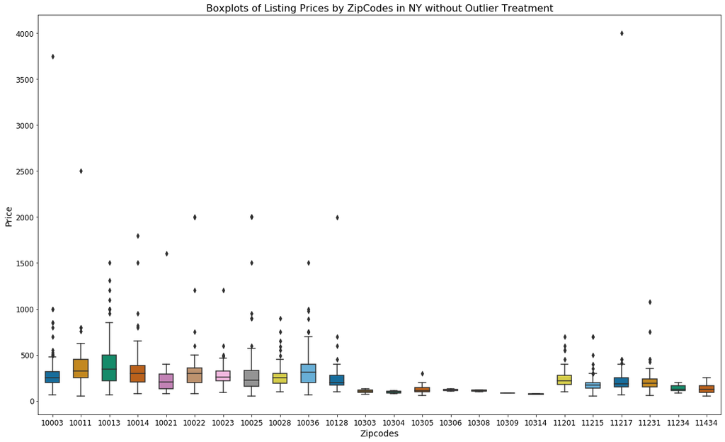

```python
plt.figure(figsize=(20,12))
bplot = sns.boxplot(y='price', x='Zipcodes',
                 data=final,
                 width=0.5,
                 palette="colorblind")

bplot.axes.set_title("Boxplots of Listing Prices by ZipCodes in NY without Outlier Treatment",
                    fontsize=16)

bplot.set_xlabel("Zipcodes",
                fontsize=14)

bplot.set_ylabel("Price",
                fontsize=14)

bplot.tick_params(labelsize=12)
```

Its observed that some zipcodes such as 10003 and 11217 has some abnormally high values which should be capped

### Capping outliers

Function to cap outliers in prices that are abnormally high or low

```python
def outlier(col):
    percentiles = col.quantile([0.01,0.99]).values
    col = np.clip(col, percentiles[0], percentiles[1])
    return col

final.price=outlier(final.price)
```

```python
final.price.describe().round()
```

```
count    1564.0
mean      277.0
std       195.0
min        68.0
25%       165.0
50%       228.0
75%       321.0
max      1379.0
Name: price, dtype: float64
```

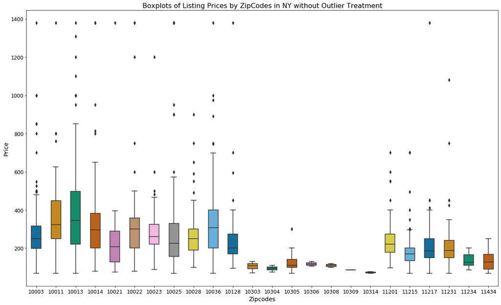

```python
plt.figure(figsize=(20,12))
bplot = sns.boxplot(y='price', x='Zipcodes',
                 data=final,
                 width=0.5,
                 palette="colorblind")

bplot.axes.set_title("Boxplots of Listing Prices by ZipCodes in NY without Outlier Treatment",
                    fontsize=16)

bplot.set_xlabel("Zipcodes",
                fontsize=14)

bplot.set_ylabel("Price",
                fontsize=14)

bplot.tick_params(labelsize=12)
```

### Price Distribution by zipCode and Neighbourhood

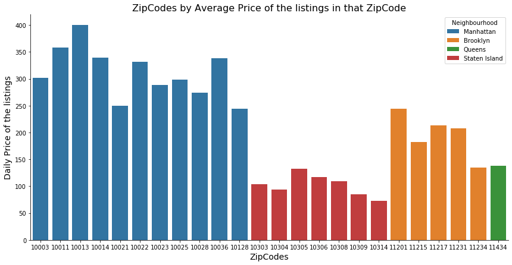

```python
grouped_values=final.groupby(['Neighbourhood','Zipcodes']).agg({'price':'mean'}).sort_values(by='price',ascending=False).reset_index()
plt.figure(figsize=(15,12))

bar=sns.factorplot(x='Zipcodes',y='price',hue='Neighbourhood',data=grouped_values,
                        size=6,  aspect=2,
                        kind='bar',
                        dodge=False,legend_out=False)
bar.ax.set_title("ZipCodes by Average Price of the listings in that ZipCode",fontsize=16)

bar.set_xlabels("ZipCodes",
                fontsize=14).add_legend(title='Neighbourhood')


bar.set_ylabels("Daily Price of the listings",
                fontsize=14)
```

### Cost Distribution by Zipcode and Neighbourhood

```python
avg_cost_latest = zillow_df.copy()
avg_cost_latest = avg_cost_latest.loc[:, ['RegionName']]
avg_cost_latest['avg_cost'] = zillow_df[zillow_df.columns[-6:]].mean(axis =1)
```

```python
final_data_cost = avg_cost_latest.merge(final, how='inner', left_on='RegionName', right_on='Zipcodes')
```

Similar to the price listings, Manhattan is observed to have the highest cost of properties followed by Brooklyn and Staten Islands

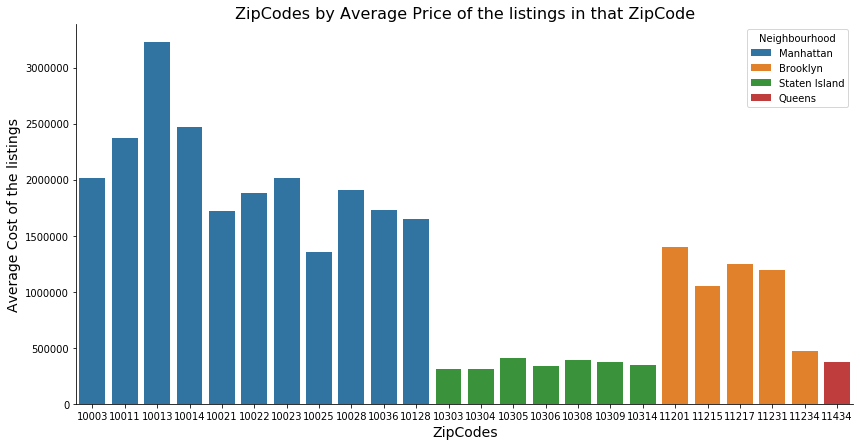

```python
grouped_values_cost=final_data_cost.groupby(['Neighbourhood','Zipcodes']).agg({'avg_cost':'mean'}).sort_values(by='avg_cost',ascending=False).reset_index()
plt.figure(figsize=(15,12))

bar=sns.factorplot(x='Zipcodes',y='avg_cost',hue='Neighbourhood',data=grouped_values_cost,
                        size=6,  aspect=2,
                        kind='bar',
                        dodge=False,legend_out=False)

bar.ax.set_title("ZipCodes by Average Price of the listings in that ZipCode",fontsize=16)

bar.set_xlabels("ZipCodes",
                fontsize=14).add_legend(title='Neighbourhood')


bar.set_ylabels("Average Cost of the listings",
                fontsize=14)
```

### Cost Trends over the last 12 months

Since the median costs does not vary much over a time frame of past 12 months, inorder for accurate results and to take the recency factor into account, an average of past 6 months cost data has been considered for analysis

```python
cost_trend=pd.concat([final[['Zipcodes','Neighbourhood']],final.iloc[:,6:18]],axis = 1)
cost_trend=cost_trend.melt(id_vars=['Zipcodes','Neighbourhood'],var_name="Year",value_name="Median Price")
cost_trend=cost_trend.drop_duplicates()
cost_trend.Zipcodes=cost_trend.Zipcodes.astype(float).astype(int).astype(str)
```

```python
df = cost_trend
fig = px.line(df, x="Year", y="Median Price", color="Zipcodes", facet_row="Neighbourhood",width=800,height=800)
fig.for_each_annotation(lambda a: a.update(text=a.text.replace("Neighbourhood=", "")))
#fig.for_each_annotation(lambda a: a.update(text=a.text.replace("MedianPrice", "")))
fig.for_each_trace(lambda t: t.update(name=t.name.replace("Zipcodes=", "")))
#fig.update_yaxes(matches=None)
fig.update_layout(showlegend=True)
fig.update_xaxes(ticks="inside",nticks=20,showline=True, linewidth=2, linecolor='black', mirror=True)
fig.update_yaxes(ticks="inside", col=1,showline=True, linewidth=2, linecolor='black', mirror=True)
fig.update_layout(legend=dict(x=0, y=-0.2))
fig.update_layout(legend_orientation="h")


fig.update_traces(hoverinfo='text+name', mode='lines+markers')
fig.update_layout(
     title={
        'text': "Cost Trend of the Properties by ZipCode for last 12 Months",
        'y':0.96,
        'x':0.5,
        'xanchor': 'center',
        'yanchor': 'top'},

    xaxis_title="Year",
    yaxis_title="Median Price",
    font=dict(
        family="Courier New, monospace",
        size=10,
        color="#7f7f7f"))
fig.show()
```

[interactive chart not shown]

## Cost Benefit Analysis

The Zipcodes have been split across four quadrants to identify profitable ones

High cost High return zipcodes: These are the Zipcodes that are profitable but do not make very high profits due to the high costs involved at the time of purchase. Most of the Manhattan properties fall in this category Example ZipCodes:

##### 10014

##### 10013

##### 10011

Low Cost High return zipcodes:These are highly recommended ZipCodes as they make high profits with lesser investment. However not many zipcodes fall into this category Example zipcodes:

##### 10025

##### 10036

Low cost Low return zipcodes:These Zipcodes are recommended after the ones in the Second Quadrant. they involve lesser cost and lesser or higher price/revenue. Example zipcodes:

##### 11434

##### 10306

##### 10305

High cost Low return zipcodes: There are no ZipCodes this belong to this Quadrant

```python
final_data_cost['Normalized_price'] = (final_data_cost.price-final_data_cost.price.mean())/final_data_cost.price.std()
final_data_cost['Normalized_cost'] = (final_data_cost.avg_cost-final_data_cost.avg_cost.mean())/final_data_cost.avg_cost.std()
```

```python
df = final_data_cost
grouped_values_bubble=final_data_cost.groupby(['Neighbourhood','Zipcodes']).agg({'Normalized_cost':'mean','Normalized_price':'mean'}).reset_index()
fig = px.scatter(grouped_values_bubble, x="Normalized_cost", y="Normalized_price", color="Neighbourhood",
                 hover_data=['Zipcodes'],size_max=60,width=800, height=600)
fig.for_each_trace(lambda t: t.update(name=t.name.replace("Neighbourhood=", "")))
fig.update_traces(mode="markers",marker=dict(size=12))

fig.update_layout(
     title={
        'text': "Cost Benefit Analysis of Zipcodes",
        'y':0.96,
        'x':0.5,
        'xanchor': 'center',
        'yanchor': 'top'},

    xaxis_title="Normalized Cost",
    yaxis_title="Normalized Price",
    font=dict(
        family="Courier New, monospace",
        size=12,
        color="#7f7f7f"))

fig.update_layout(
    autosize=False,
    width=800,
    height=600)



fig.add_shape(
        go.layout.Shape(
            type="line",
            x0=0,
            y0=2,
            x1=0,
            y1=-2,
            line=dict(
                color="grey",
                width=3,dash="dashdot"
            )
))
fig.add_shape(
        go.layout.Shape(
            type="line",
            x0=-3,
            y0=-0,
            x1=3,
            y1=0,
            line=dict(
                color="grey",
                width=4,
                dash="dashdot",
            ),
    ))

fig.show()
```

[interactive chart not shown]

## BreakEven Analysis

### Top Zipcodes by breakeven period

The break-even point is the point at which total cost and total revenue are equal. There is no net loss or gain. At break-even point revenues are equal to exactly all of the expenses on a single income statement prepared under the accrual method of accounting.

The break-even point for this business case can be determined as given below

### BreakevenPoint = AssetCost / (DailyPrice∗availability∗OccupancyRate)

```python
breakeven_analysis =final_data_cost.groupby(['Neighbourhood','Zipcodes']).agg({'price':'mean','avg_cost':'mean'}).rename(columns={'price': 'Avg_price','avg_cost':'Mean_cost'}).round({'Avg_price':2,'Mean cost':2}).reset_index()
breakeven_analysis['Breakeven_years']= round(breakeven_analysis.Mean_cost/(breakeven_analysis.Avg_price*availability*occupancy),2)
```

The below graph shows the breakeven points(in years) sorted from lowest to highest based on the neighbourhoods.

It is observed that the zipcodes 11434,10306,10303,10305,10304 are the ones that recoup the entire money spent on the property the earliest. It should be noted that most of the zipcodes in the Staten Island neighbourhood breaks even early as when compared to rest.

```python
breakeven_analysis["Zip-Neighbourhood"] = breakeven_analysis["Zipcodes"].map(str)+ '-'+breakeven_analysis["Neighbourhood"].str[:1]
fig = px.bar(breakeven_analysis,  x="Zip-Neighbourhood", y="Breakeven_years",
             hover_data=['Neighbourhood'], color='Neighbourhood',
             height=500,width=1000)
fig.for_each_trace(lambda t: t.update(name=t.name.replace("Neighbourhood=", "")))
fig.update_xaxes(categoryorder="total ascending")
fig.update_layout(
     title={
        'text': "BreakEven point analysis by Zipcode",
        'y':0.96,
        'x':0.5,
        'xanchor': 'center',
        'yanchor': 'top'},

    xaxis_title="Zip-Neighbourhood",
    yaxis_title="BreakEven Time in Years",
    font=dict(
        family="Courier New, monospace",
        size=12,
        color="#7f7f7f"))
fig.update_layout(legend_orientation="v")


fig.show()
```

[interactive chart not shown]

#### Breakeven Analysis by Zipcode on Map

ZIP Codes with bargraphs isn't a very intuitive way to present results by itself. Presenting the the same on a map would help the real estate company visually understand the results better.

The size of the bubble is inversely proportional to the breakeven value in years, The larger the size of the bubbles the shorter is the time to breakeven and vice-versa. The bubbles can be clicked to see all the information associated with each point.

```python
map_data =final_data_cost.groupby(['Neighbourhood','Zipcodes']).agg({'price':'mean','avg_cost':'mean','latitude':'mean','longitude':'mean'}).rename(columns={'price': 'Avg_price','avg_cost':'Mean_cost','latitude':'Latitude','longitude':'Longitude'}).round({'Avg_price':2,'Mean cost':2}).reset_index()
map_data['Breakeven_years']= round(map_data.Mean_cost/(map_data.Avg_price*availability*occupancy),2)

folium_map = folium.Map(location=[40.67, -74],
                        zoom_start=11,
                        tiles="CartoDB dark_matter")
for index,row in map_data.iterrows():
    popup_text = "Zipcode: {}<br> Neighbourhood: {}<br> Breakeven years: {}"
    popup_text = popup_text.format(row["Zipcodes"],row["Neighbourhood"],row["Breakeven_years"])
    if row["Neighbourhood"]=='Manhattan':
        color="#FFCE00" # orange
    elif row["Neighbourhood"]=='Queens':
        color="#E37222"
    elif row["Neighbourhood"]=='Staten Island':
        color="#0375B4" # blue
    else :
        color="#0A8A9F" # teal

    radius= row['Breakeven_years']
    folium.CircleMarker(location=(row["Latitude"],row["Longitude"]),radius=-radius+35,color=color,popup=popup_text,
                        fill=True).add_to(folium_map)

folium_map
```

[interactive chart not shown]

## Competitive Analysis

Venturing into a market without understanding the competition is risky. Identifying our competitors is important before we finalize our business strategies. It is vital to the success of a new or existing business because it reduces risk, time, required resources, and expense.

As per Airbnb, a super host is someone who provides a shining example for other hosts, and provide extraordinary experiences for their guests. So, it is important to look where our competition is before we start investing.

Rather than looking at the number of superhosts, an analysis of their proportion out of the total listings would give us a better idea of the competition.

The size of the bubbles represents the percentage of super hosts out of the total listings. We may choose to ignore the zipcode 10308 in Staten Island as this has only 2 listings. However, it can be observed that in Queens, out of the 16 listings 8 of them (50%) are superhosts making this neighbourhood highly competitive for someone who is venturing into this business.

```python
final_org=final.groupby(['Zipcodes','Neighbourhood']).agg({'latitude':'mean','longitude':'mean','host_is_superhost':'count'}).rename(columns={'latitude':'Latitude','longitude':'Longitude'}).reset_index()
final_sh=final[final.host_is_superhost=='t']
final_sh=final_sh.groupby(['Zipcodes','Neighbourhood'])['host_is_superhost'].count().reset_index()
final_competitors = final_org.merge(final_sh, how='inner', left_on='Zipcodes', right_on='Zipcodes')
final_competitors=final_competitors.drop_duplicates()
final_competitors = pd.merge(final_org,final_sh[['Zipcodes','host_is_superhost']],on='Zipcodes', how='inner')
final_competitors=final_competitors.rename(columns={'host_is_superhost_x':'Total_listings','host_is_superhost_y':'Total_super_hosts'})
final_competitors['Percentage_of_super_hosts']= round(final_competitors.Total_super_hosts/final_competitors.Total_listings * 100,2)
```

```python
folium_map = folium.Map(location=[40.67, -74],
                        zoom_start=11,
                        tiles="CartoDB dark_matter")
for index,row in final_competitors.iterrows():
    popup_text = "Zipcode: {}<br> Neighbourhood: {}<br> Listings: {}<br> Superhosts: {}<br> Superhosts %: {}"
    popup_text = popup_text.format(row["Zipcodes"],row["Neighbourhood"],row["Total_listings"],row["Total_super_hosts"],row["Percentage_of_super_hosts"])
    if row["Neighbourhood"]=='Manhattan':
        color="#FFCE00" # orange
    elif row["Neighbourhood"]=='Queens':
        color="#E37222"
    elif row["Neighbourhood"]=='Staten Island':
        color="#0375B4" # blue
    else :
        color="#0A8A9F" # teal

    radius= row['Percentage_of_super_hosts']
    folium.CircleMarker(location=(row["Latitude"],row["Longitude"]),radius=radius/2,color=color,popup=popup_text,
                        fill=True).add_to(folium_map)

folium_map
```

[interactive chart not shown]

## EXECUTIVE SUMMARY

### Problem Statement

Analyze the Airbnb and Zillow datasets to help a real estate client understand which zip codes would generate the most profit on short term rentals within New York City for 2 bedroom apartments

### Approach

A thorough study of the data from the different sources was performed followed by data munging and cleaning steps

A basic exploratory data analysis was performed to find the number of listings by ZipCodes

Created different plots to understand the price and cost distribution

Performed a Price vs Cost Quadrant Analysis to understand the high-risk and high-return ZipCodes

Performed Breakeven Analysis to understand the ZipCodes which recoup the investment the earliest

Performed a Competitve Analysis to understand the competiton and identify highly competitive Zipcodes before investing

### Major Insights and Findings

From a low-risk and high-return on investment standpoint the zipcodes 10025 and 10036 in Mahattan are good investment options

From a low-risk and moderate-return standpoint, I would recommend the zipcode 11434 in Queens and the zipcodes 10306 and 10305 in Staten Island as potentially good avenues of investment

From a breakeven perspective, I would recommend zipcode 11434 in Queens as the best ZipCode to invest in, followed by 10306 and 10303 in Staten Islands

From a competition perspective, it is recommeneded the client should exercise caution while investing in Queens or Staten Islands as these neighbourhoods have a significant proportion of listings that provide high quality stay to its customers

### Future Steps

We could run a time series model to predict the most recent cost of the properties and thus decide which Zipcodes to invest in using our cost-benefit analysis in a more comprehensive manner

A clustering exercise based on neighbourhoods could be performed to find similar classes of ZipCode from a profitability perspective

We could run logistic regression models based on different parameters to help classify the zip codes as profitable or not

We could get more cleaner and quality data from Airbnb on Cleaning price, Occupancy rate, Promotions and Discounts to be able to get a better estimate of the revenue

Text mining could be performed on the reviews field to identify sentiments of the guests for any particluar neighborhood